# Probability - Tasks

Florian Oswald

2025-10-06

# Task 1: Probabilities

Given a fair 6-sided dice 🎲, i.e. an outcome space $\Omega = \{1,2,3,4,5,6\}$ and events

$$\begin{align}
A &= \{2,4,6\},\\
B &= \{1,3,5\}.
\end{align}$$

Define $X$ as the outcome of rolling the dice once. What is $\Pr(X \in A)$?

## Answer

In this simple sample space (i.e. a sample space where each element has the same probability of occuring), we can just count. There are 6 elements in $\Omega$, event $A$ contains 3 of those, i.e. in 3 out of 6 cases $X$ could land on an even number. That is

$$\Pr(X \in A) = \frac{\text{number of
success}}{\text{all potential outcomes}} = \frac{3}{6} =
0.5$$

# Task 2: 2 Dice

Given two fair 6-sided dice 🎲 🎲, what is the probability of obtaining *at least* once the face “5”?

Again, counting. The total number of events from 2 dice are

```r
o = outer(1:6,1:6,FUN = function(x,y){paste0("(",x,",",y,")")})
o
```

```
##      [,1]    [,2]    [,3]    [,4]    [,5]    [,6]
## [1,] "(1,1)" "(1,2)" "(1,3)" "(1,4)" "(1,5)" "(1,6)"
## [2,] "(2,1)" "(2,2)" "(2,3)" "(2,4)" "(2,5)" "(2,6)"
## [3,] "(3,1)" "(3,2)" "(3,3)" "(3,4)" "(3,5)" "(3,6)"
## [4,] "(4,1)" "(4,2)" "(4,3)" "(4,4)" "(4,5)" "(4,6)"
## [5,] "(5,1)" "(5,2)" "(5,3)" "(5,4)" "(5,5)" "(5,6)"
## [6,] "(6,1)" "(6,2)" "(6,3)" "(6,4)" "(6,5)" "(6,6)"
```

i.e. for each potential value of the first dice (`1,2,...,6`) we have 6 values for the second dice (`1,2,...,6`). In total, 36 potential outcomes.

How many of those correspond to *at least* once the face “5”? Well, just look for “5” above! (Caution, don’t count “(5,5)” twice!)

So, we have

```r
o[,5]
```

```
## [1] "(1,5)" "(2,5)" "(3,5)" "(4,5)" "(5,5)" "(6,5)"
```

and

```r
o[5,]
```

```
## [1] "(5,1)" "(5,2)" "(5,3)" "(5,4)" "(5,5)" "(5,6)"
```

which together would make 12 elements, but we must not count “(5,5)” twice. Therefore,

$$\Pr(\text{At least once "5"})
= \frac{11}{36}$$

# Task 3: Computing Variance by hand

1. Compute the variance of one 6-sided dice!

First a trick. Oftentimes it’s easier to work with the following formulation of variance:

$$\begin{align}
Var(X) &= E[(Y-\mu_Y)^2] \\
&= E[Y^2 -2 Y \mu_Y + \mu_Y^2] \\
&= E(X^2) - E(2 Y \mu_Y) + E(\mu_x^2) \\
&= E(X^2) - 2 \mu_Y E(Y) + \mu_x^2 \\
&= E(X^2) - 2 \mu_Y^2 + \mu_x^2 \\
&= E(X^2) - \mu_Y^2 \\
\end{align}$$

2. compute the variance of $X \sim \text{Bernoulli}(p)$!

Again,

$$Var(X) = E(X^2) - \mu_x^2 = E(X^2) -
p^2$$
$E(X^2) = p 1^2 + (1-p) 0^2 = p$. this gives us

$$Var(X) = E(X^2) - \mu_x^2 = p - p^2 =
p(1-p)$$
Bonus question: what value of $p$ maximizes this variance?

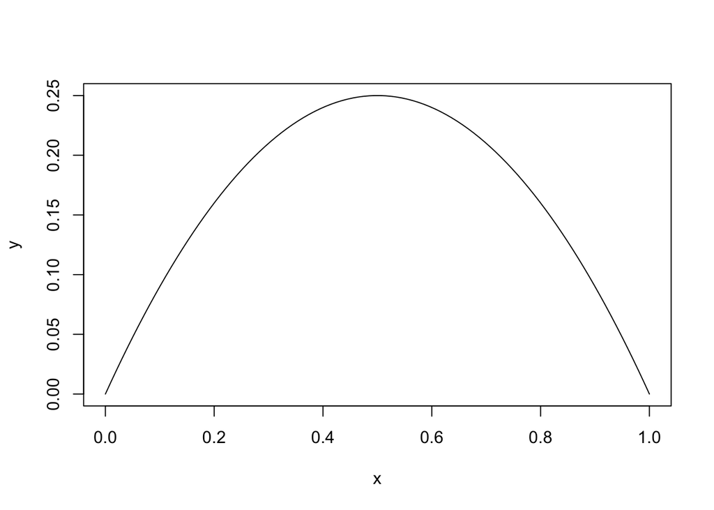

# Task 4

```r
r = data.frame(x0 = c(0.15,0.15),x1 = c(0.07,0.63))
names(r) <- c("Rain (X=0)", "No Rain (X=1)")
rownames(r) <- c("Long Commute (Y=0)", "Short Commute (Y=1)")
r
```

```
##                     Rain (X=0) No Rain (X=1)
## Long Commute (Y=0)        0.15          0.07
## Short Commute (Y=1)       0.15          0.63
```

1. Compute the marginal distribution of $X$
2. Compute the marginal distribution of $Y$

$$\Pr(Y = 0) = \Pr(Y=0, X = 0) + \Pr(Y=0,
X = 1) = 0.22$$
$$\Pr(Y = 1) =
\Pr(Y=1, X = 0) + \Pr(Y=1, X = 1) = 0.78$$
In general, just sum across rows (or columns):

```r
(PrY = rowSums(r))
```

```
##  Long Commute (Y=0) Short Commute (Y=1)
##                0.22                0.78
```

```r
(PrX = colSums(r))
```

```
##    Rain (X=0) No Rain (X=1)
##           0.3           0.7
```

# Task 5: compute conditional distribution

Consider

```
##                     Rain (X=0) No Rain (X=1)
## Long Commute (Y=0)        0.15          0.07
## Short Commute (Y=1)       0.15          0.63
```

- Suppose we know that it does not rain $x = 1$. What is the distribution of $Y$, *given* this knowledge, i.e. what is the distribution $\Pr(Y|X=1)$ ?

## answer

first, we can just grab the column of data where our imposed condition is true:

```r
r[ , 2]
```

```
## [1] 0.07 0.63
```

# Task 6: More conditional dists

```r
gapminder <- dslabs::gapminder
gapminder_new <- gapminder %>%
  filter(year == 2015) %>%
  mutate(fertility_above_2 = (fertility > 2.1)) # dummy variable for fertility rate above replacement rate
gn = gapminder_new %>% filter(country != "Greenland")
abs_tab = table(gn$continent, gn$fertility_above_2)
prop_tab = round(prop.table(abs_tab),2)
```

```r
prop_tab[,1] / sum(prop_tab[,1])
```

```
##     Africa   Americas       Asia     Europe    Oceania
## 0.02325581 0.18604651 0.25581395 0.48837209 0.04651163
```

```r
prop_tab[3,] / sum(prop_tab[3,])
```

```
##     FALSE      TRUE
## 0.4230769 0.5769231
```

```r
colSums(prop_tab)
```

```
## FALSE  TRUE
##  0.43  0.57
```

# Task 7: Conditional Expectation

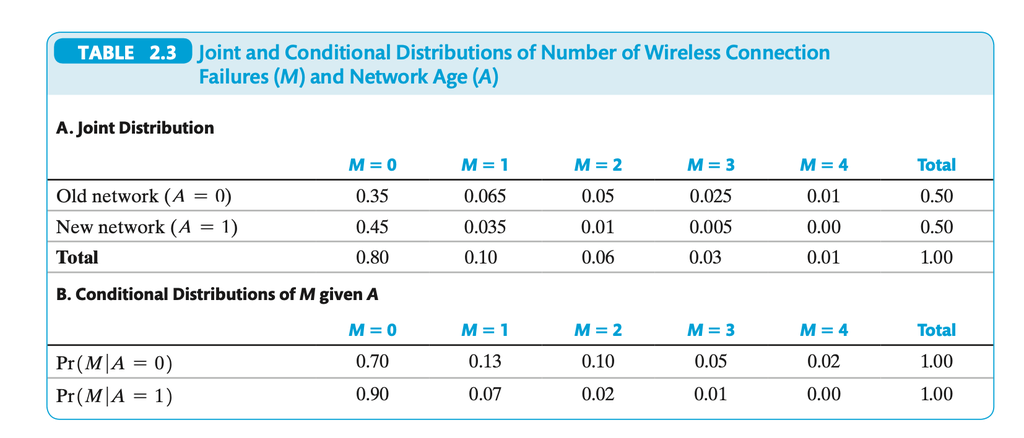

1. What is the expected value of $M$? Hint: remember the formula for $E(Y)$ from a few slides ago
2. What is the expected value of $M$ *given* $A=0$? Hint: Just replace the $\Pr$ parts in your formula!

Formula is of course

$$E(M)= \sum_i \Pr(M = m_i) m_i$$
So, what is $\Pr(M = m_i)$, i.e. the **unconditional** distribution of M? Just fill in the values:

$$0.8 \times 0 + 0.1 \times 1 + 0.06
\times 2 + 0.03 \times 3 + 0.01 \times 4 = 0.35$$

Ok, next, the whole thing given $A=0$. Just grab the correct row from the above table, and recompute.

```r
pr_a0 = c(0.7,0.13,0.1,0.05,0.02)
# check
sum(pr_a0)
```

```
## [1] 1
```

ok, we just need to sum that against values 0,1,2,3,4. That’s a range, right?

```r
pr_a0 %*% 0:4 # the %*% performs a vector multiplication. a dot-product.
```

```
##      [,1]
## [1,] 0.56
```

Well, for $A=1$ this is now super easy. Just grab the correct value from the table.

```r
pr_a1 = c(0.9,0.07,0.02,0.01,0.00)
# check
sum(pr_a1)
```

```
## [1] 1
```

```r
pr_a1 %*% 0:4
```

```
##      [,1]
## [1,] 0.14
```

# Task 8 : Show Correlation and Conditional Mean

Show this result!

$$E(Y|X) = \mu_Y \Rightarrow cov(X,Y) = 0
\text{ and } corr(X,Y) = 0$$

- Let’s assume that both $X,Y$ have a mean of zero (if they don’t, it’s easy to transform them first)
- In that case, the covariance simplifies:

$$\begin{align}
E\left[ (X - \mu_X) (Y- \mu_Y) \right] &= \\
E\left[ (XY - X \mu_Y - \mu_X Y + \mu_X\mu_Y) \right] &=\\
E\left[ XY \right]
\end{align}$$

- Ok, use the LIE

$$\begin{align}
E\left[ XY \right] &= \\
E\left[ E(YX | X) \right] &= \\
E\left[ E(Y | X) X\right] &= 0
\end{align}$$

because we were told that $E(Y|X) = 0$ (first part of statement!)

- So, if $E\left[ XY \right] =0$, and if that is our expression for covariance, well that means that covariance is zero.
- Covariance zero implies correlation zero.

# Task 9: Variance of the Sample Average

- Similarly to the *mean* of the sample average, here we just plug in the expression for $\bar{y}$ into the variance formula:

$$var(\bar{y}) = var\left(
\frac{1}{n}\sum_{i=1}^n y_i \right) = \frac{\sigma_Y^2}{n}$$

- Show this result!
1. First, we need to know that $var(x + y) = var(x) + var(y) + 2 cov(x,y)$. You can try to show that yourself (or ask Kacper!)
2. Then, we need to know that $var(a X)$ where $a$ is a constant is equal to $a^2 var(x)$

$$\begin{align}
var(a X) &= E\left[ (aX)^2\right] - E\left[ (aX)\right]^2\\
&= E\left[ (aX)^2\right] - a^2 \mu_X^2\\
&= a^2 E\left[ X^2\right] - a^2 \mu_X^2\\
&= a^2 \left( E\left[ X^2\right] - \mu_X^2 \right) \\
&= a^2 var(x)
\end{align}$$

3. Great. Now we can tackle this expression head on:

$$\begin{align}
var(\bar{y}) &= var\left( \frac{1}{n}\sum_{i=1}^n y_i \right)\\
&= \frac{1}{n^2}var\left( \sum_{i=1}^n y_i \right)
\end{align}$$

4. So far so good. Let’s us prove the rest by induction. That is, we first show that this works for $n=2$, then for $n=3$, and so on until we think it’s a general result:
- If $n=2$, and given that the $y_i$s are i.i.d., we have that (by result 1 above)

$$var(y_1 + y_2) = var(y_1) + var(y_2) + 2
cov(y_1, y_2)$$

the last term being equal to zero courtesy of i.i.d. So, that means that this is actually just

$$var(y_1 + y_2) = var(y_1) + var(y_2) =
2 \sigma^2$$

- What about $n=3$?

$$var(y_1 + y_2 + y_3) = var(y_1) +
var(y_2) + var(y_3) + 2 cov(y_1, y_2) + 2 cov(y_1, y_3) + 2 cov(y_2,
y_3)$$

So, that’s
$$var(y_1 + y_2 + y_3) =
3\sigma^2$$

- So, we conclude that for $n$ we have
  $$var\left( \sum_{i=1}^n y_i \right) = n
  \sigma^2$$
  .

This means that we end up with

$$\begin{align}
var(\bar{y}) &= var\left( \frac{1}{n}\sum_{i=1}^n y_i \right)\\
&= \frac{1}{n^2}var\left( \sum_{i=1}^n y_i \right)\\
&= \frac{1}{n^2}n \sigma_Y^2\\
&= \frac{1}{n}\sigma_Y^2\\
\end{align}$$

# Task 9: Show That $E$ is a linear operator

Remember the definition of expected value. Expected value is a probability-weighted sum. When you add two random variables, you’re adding their outcomes in each state of the world, then taking the probability-weighted average. Because multiplication distributes over addition, you can either:

1. Add the outcomes first, then weight by probabilities, OR
2. Weight each variable separately, then add together.

Both give the same answer.

Here, we want to establish that

$$E(X+Y) = E(X) + E(Y)$$

but that

$$E(g(X)) \neq g\left( E(X)
\right)$$

for some non-linear function $g(x)$.

## Example with linear operation

**Setup:** You’re taking two classes. Your grade is uncertain.

**Class A (X):**

- 1/4 chance you get 80
- 3/4 chance you get 60

**Class B (Y):**

- 1/3 chance you get 90
- 2/3 chance you get 60

Assume independence between X and Y.

### Method 1: E(X + Y) directly

All possible outcomes for X + Y:

| X | Y | X + Y | Probability |
| --- | --- | --- | --- |
| 80 | 90 | 170 | (1/4)(1/3) = 1/12 |
| 80 | 60 | 140 | (1/4)(2/3) = 2/12 |
| 60 | 90 | 150 | (3/4)(1/3) = 3/12 |
| 60 | 60 | 120 | (3/4)(2/3) = 6/12 |

$$E(X + Y) = 170 \cdot \frac{1}{12} + 140
\cdot \frac{2}{12} + 150 \cdot \frac{3}{12} + 120 \cdot
\frac{6}{12}$$

$$= \frac{170 + 280 + 450 + 720}{12} =
\frac{1620}{12} = 135$$

### Method 2: E(X) + E(Y)

**Calculate E(X):**
$$E(X) =
80 \cdot \frac{1}{4} + 60 \cdot \frac{3}{4} = \frac{80 + 180}{4} =
\frac{260}{4} = 65$$

**Calculate E(Y):**
$$E(Y) =
90 \cdot \frac{1}{3} + 60 \cdot \frac{2}{3} = \frac{90 + 120}{3} =
\frac{210}{3} = 70$$

**Sum:**
$$E(X) + E(Y) = 65 +
70 = 135$$

✓ **Same answer!**

## Weights do Not distribute equally over nonlinear functions

If we transform the values nonlinearly (i.e. we don’t add/substract the same amount to each value but instead we scale them unequally in some way), we **distort** the average.

Just take the dice $X \in \{1,2,3,4,5,6\}$ each with $p=1/6$. Let’s take

$$g(x) = x^2$$
as a simple example.

We know that $E(X) = 3.5$. So, the first part is simply

$$g\left( E(X) \right) = 3.5^2 =
12.25$$

But the second part is
$$E(g(X)) = E(X^2)
= \frac{1}{6}(1^2 + 2^2 + \dots + 6^2) = \frac{1}{6}91 =
15.17$$

So, the two results are clearly different.